# Pair assessment INFO634

### Question 6:

Based on the results from 5) above, analyse the residuals to determine if the assumptions underlying your regression analysis are valid. You need to provide a visualisation for this purpose and justify your answer.

Plotting the residuals:

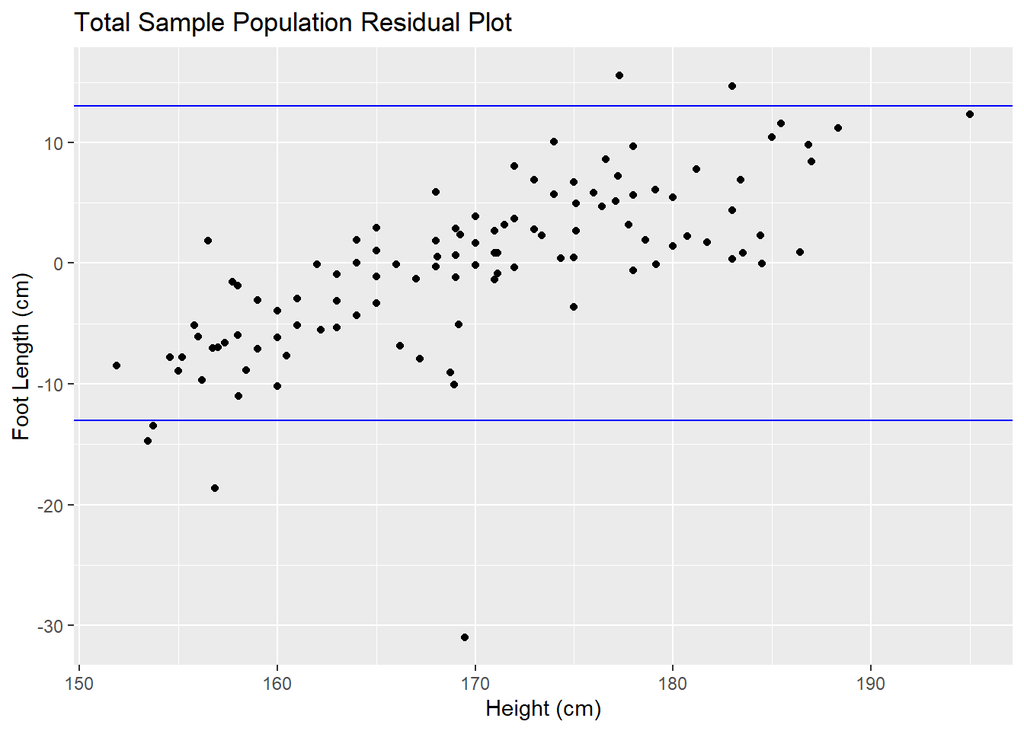

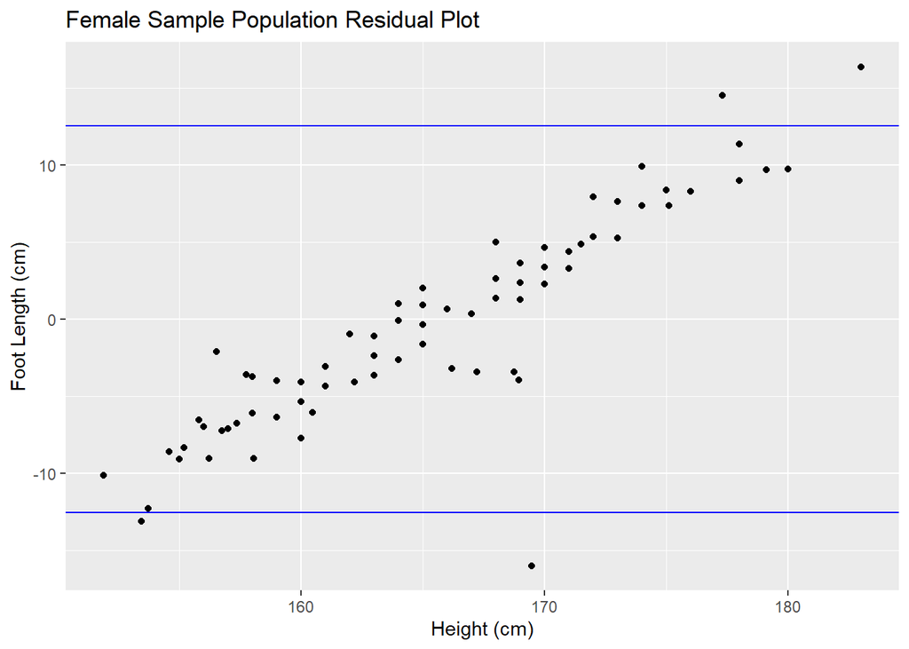

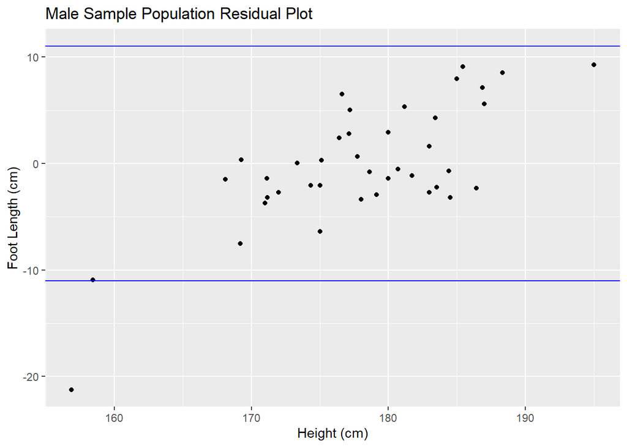

Based on our analysis of the residuals, the majority of the data of the sample population does fall between +-2 Standard Deviations of the mean, however the data does not meet the assumption of linearity in that not all the residuals are distributed within +- 2 Standard Deviations.

The female sample population has more outliers when compared with the male sample population as seen on the graphs above. However, the outlier residual for the female sample is smaller than the male outlier.